# Ejercicio 4: Regresión Lineal Múltiple: Análisis de Salarios

#### Paquetes

```r
#install.packages("R2OpenBUGS")
#install.packages("R2jags")
```

#### Librerias

```r
library(R2OpenBUGS)
library(R2jags)
```

#### -Working directory-

```r
wdir<-"/Users/guillemontanari/ITAM/github/GLM2016/RegresionLinealJAGS"
setwd(wdir)
```

### Funciones Útiles

```r
prob<-function(x){
  out<-min(length(x[x>0])/length(x),length(x[x<0])/length(x))
  out
}
```

Un investigador desea evaluar la relación entre el salario anual de trabajadores de una compañía de nivel medio y alto (Y, en miles de dólares) y el índice de calidad de trabajo (X1), número de años de experiencia (X2) y el índice de éxito en publicaciones (X3). La muestra consiste de 24 trabajadores. a) Realiza un análisis Bayesiano completo de los datos

b)obtén las predicciones de salarios para 3 nuevos empleados con variables explicativas: x1F= 5.4,17,6.0 x2F= 6.2,12,5.8 x1F= 6.4,21,6.1

### Parte a: Análisis Bayesiano completo

Cargo datos

```r
#salarios.df <- read.table("salarios.csv", header = TRUE, sep=",")
#summary(salarios.df)
salarios<-read.table("http://allman.rhon.itam.mx/~lnieto/index_archivos/salarios.txt",header=TRUE)
n<-nrow(salarios)
summary(salarios)
```

```
       Y               X1              X2              X3
 Min.   :30.10   Min.   :3.100   Min.   : 5.00   Min.   :3.500
 1st Qu.:35.70   1st Qu.:4.425   1st Qu.:17.25   1st Qu.:5.000
 Median :38.85   Median :5.400   Median :25.00   Median :6.000
 Mean   :39.50   Mean   :5.358   Mean   :24.96   Mean   :5.987
 3rd Qu.:42.92   3rd Qu.:6.275   3rd Qu.:33.25   3rd Qu.:7.000
 Max.   :52.90   Max.   :8.000   Max.   :47.00   Max.   :8.300
```

Defino los datos sin escalar para que calcule las yf

```r
x1f<-c(5.4,6.2,6.4)
x2f<-c(17,12,21)
x3f<-c(6.0,5.8,6.1)
m<-3
```

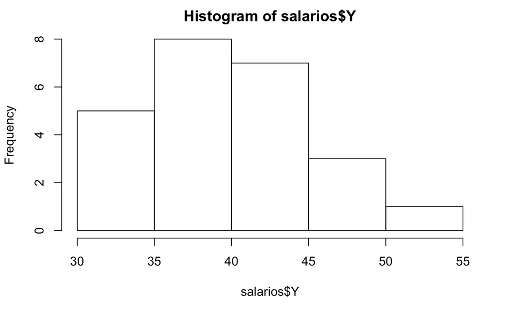

```r
hist(salarios$Y)
```

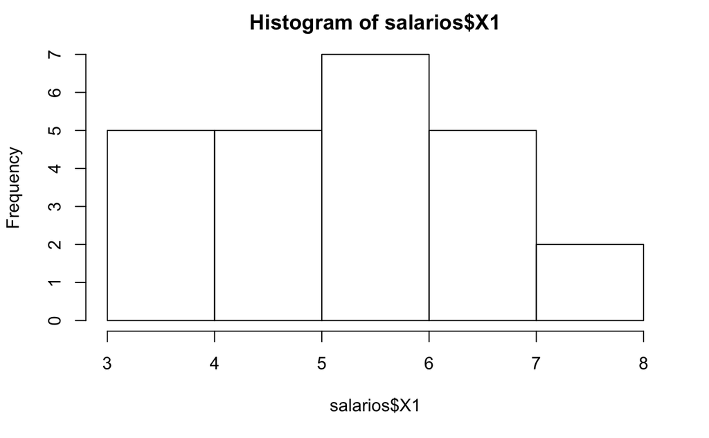

```r
hist(salarios$X1)
```

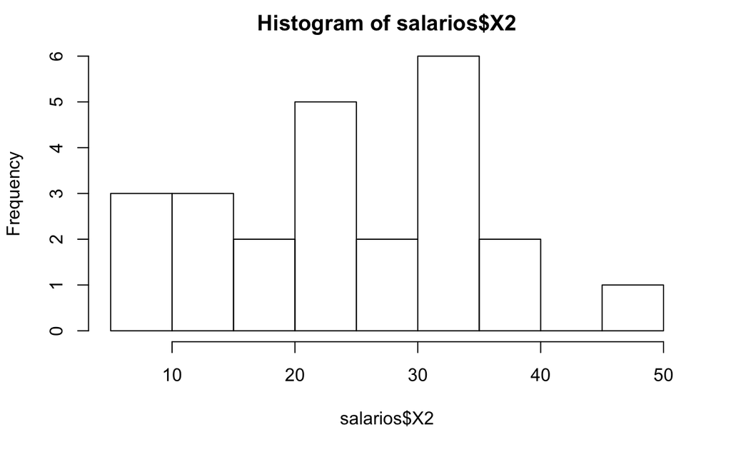

```r
hist(salarios$X2)
```

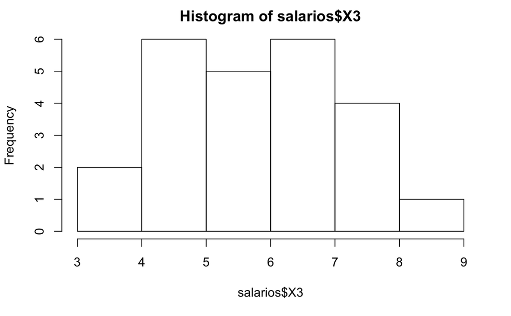

```r
hist(salarios$X3)
```

Cargo los datos sin escalar a una lista para que JAGS los pueda leer

```r
data <- list("n" = n,"y"=salarios$Y,"x1"=salarios$X1,"x2"=salarios$X2,
             "x3"=salarios$X3,"x1f"=x1f,"x2f"=x2f,"x3f"=x3f,"m"=m)
```

Defino los inits y parametros

```r
inits<- function(){list(beta=rep(0,4),tau=1,yf=rep(0,3))}
parameters<-c("beta","tau","yf")
```

## Ejecutamos la simulacion

```r
ej3.sim<-jags(data,inits,parameters,model.file="Ej4_1.txt",
              n.iter=100000,n.chains=1,n.burnin=10000,n.thin=1)
```

### Monitoreamos la cadena

#### Traza

```r
#traceplot(ej3.sim)
```

#### Cadena - Analizo Beta2 (Pendiente)

```r
out<-ej3.sim$BUGSoutput$sims.list
# Guardo los valores de Beta2 en Z: Beta2 son los coeficientes asociados a las x2 que es la pendiente
z<-out$beta[,2]
# Defino 4 zonas de ploteo
par(mfrow=c(2,2))
plot(z,type="l")
plot(cumsum(z)/(1:length(z)),type="l")
```

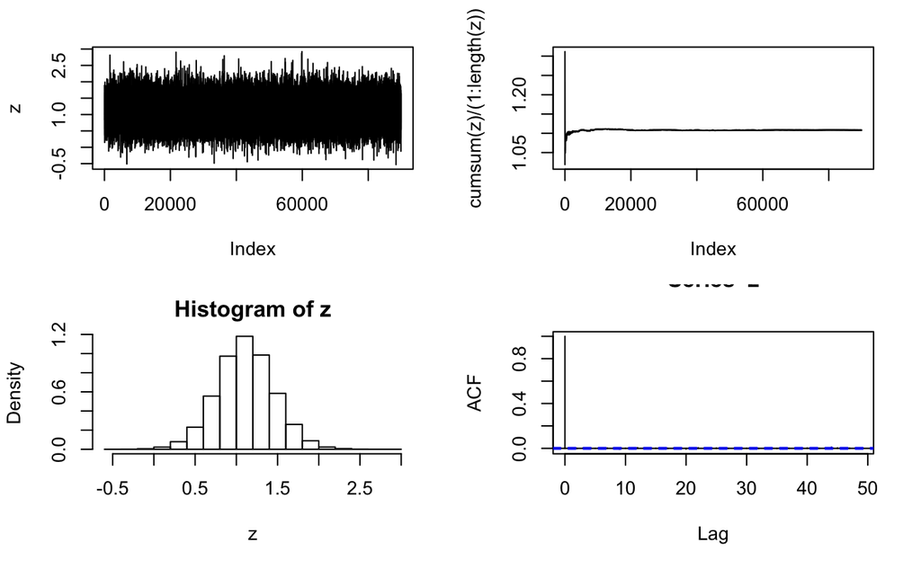

```r
hist(z,freq=FALSE)
acf(z)
```

### En la distribucion final de Beta2, la pendiente en este modelo, cercana a 1. Estoy alejada del cero, entonces mi coeficiente de la pendiente es significativamente distinta de cero. Mi histograma no tiene huecos, por lo tanto esta es una muestra de la distribucion que puedo tomar para hacer inferencias

### Hago lo mismo para Bet1, la ordenada al origen

```r
z<-out$beta[,1]
# Defino 4 zonas de ploteo
par(mfrow=c(2,2))
plot(z,type="l")
plot(cumsum(z)/(1:length(z)),type="l")
```

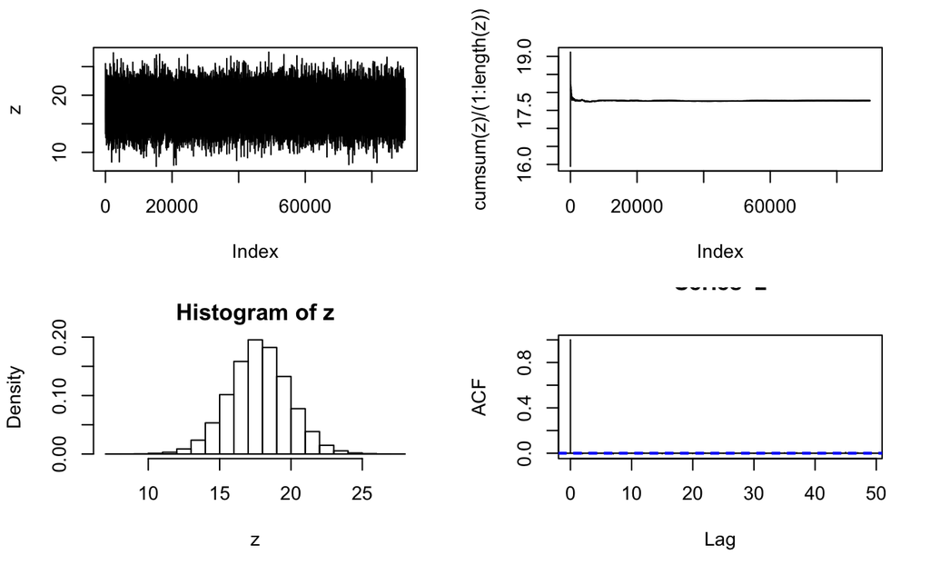

```r
hist(z,freq=FALSE)
acf(z)
```

### Beta1, toma valores alrededor de 18.

### Hago lo mismo para Beta3

```r
z<-out$beta[,3]
# Defino 4 zonas de ploteo
par(mfrow=c(2,2))
plot(z,type="l")
plot(cumsum(z)/(1:length(z)),type="l")
```

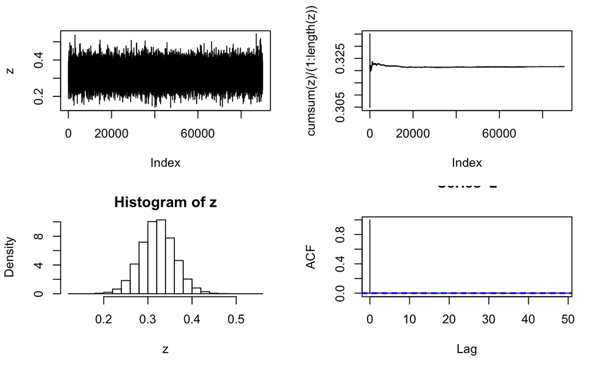

```r
hist(z,freq=FALSE)
acf(z)
```

### Hago lo mismo para Beta4

```r
z<-out$beta[,4]
# Defino 4 zonas de ploteo
par(mfrow=c(2,2))
plot(z,type="l")
plot(cumsum(z)/(1:length(z)),type="l")
```

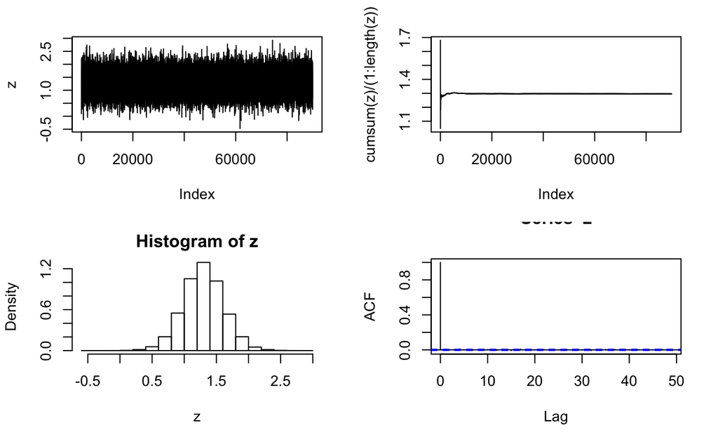

```r
hist(z,freq=FALSE)
acf(z)
```

```r
#z<-out$beta
# Defino 1 zona de ploteo
#par(mfrom=c(1,1))
#plot(z)
```

### Resumen de estimadores

```r
out.sum<-ej3.sim$BUGSoutput$summary
print(out.sum)
```

```
               mean         sd       2.5%        25%        50%        75%       97.5%
beta[1]  17.8815624 2.08129545 13.7813673 16.5235033 17.8875314 19.2456922  21.9233238
beta[2]   1.1033475 0.35002140  0.4094672  0.8754684  1.1050266  1.3339871   1.7861917
beta[3]   0.3218826 0.03871983  0.2459061  0.2965865  0.3218697  0.3469443   0.3995175
beta[4]   1.2814049 0.31620130  0.6641734  1.0740845  1.2816149  1.4858749   1.9164823
deviance 96.2501748 3.53786198 91.6122078 93.6590459 95.5237151 98.0409757 105.1461170
tau       0.3254162 0.10253576  0.1565371  0.2518610  0.3148369  0.3876468   0.5546846
yf[1]    37.0095326 1.91327950 33.2012733 35.7657253 37.0115570 38.2538574  40.7874115
yf[2]    36.0086381 2.00255618 32.0416049 34.7074447 36.0111760 37.3051597  40.0012458
yf[3]    39.5174143 1.93886208 35.6717600 38.2565787 39.5114022 40.7806333  43.3516365
```

### Si quiero estimar de manera puntua:

.Como esta es la media, es la funcion de pérdida cuadrática la que estoy usando para mi función de pérdida.

### Beta4 [ 0.67 - 1.92]

### Existe otro indicador que me es más útil para tomar la decisión de si un coeficiente está cercano a cero o no. La probabilidad de que Beta1 sea menor a cero?. Y esta es la distribución final

### Probabilidades - Beta1

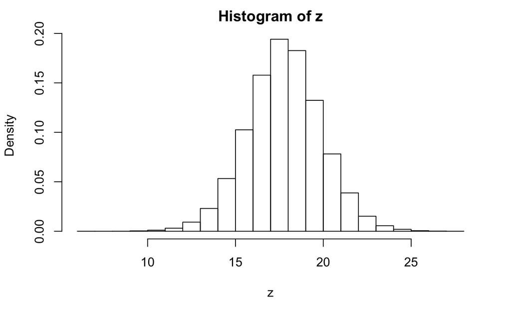

```r
z<-out$beta[,1]
hist(z,freq=FALSE)
abline(v=0,col=2)
```

### La probabilidad final de que Beta1 sea mqyor a cero:

```r
1 - prob(z)
```

[output not shown]

```r
prob(z)
```

[output not shown]

### La probabilidad de que Beta1 sea mayor a cero es 0.99, 99%, es mas que el 95% que vimos en los intervalos. Entonces mi coeficiente Beta1 es significativamente distinto de cero. La proba es chiquita lo tomo, asi es como se interpreta mi valor “p”.

### Probabilidades - Beta2

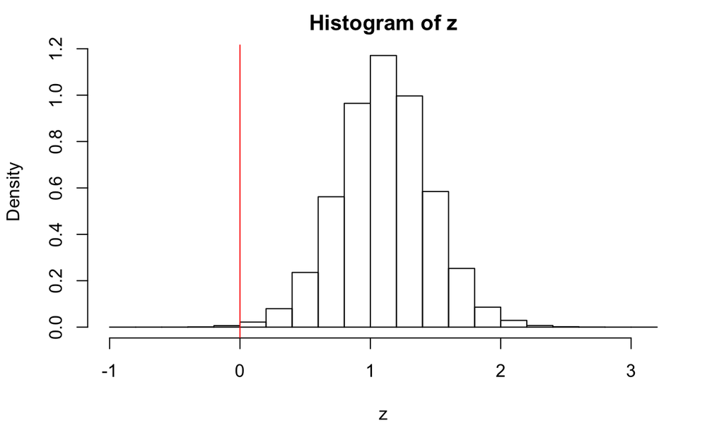

```r
z<-out$beta[,2]
hist(z,freq=FALSE)
abline(v=0,col=2)
```

### La probabilidad final de que Beta2 sea mayor a cero:

```r
1-prob(z)
```

```
[1] 0.9984889
```

```r
prob(z)
```

```
[1] 0.001511111
```

### Probabilidades - Beta3

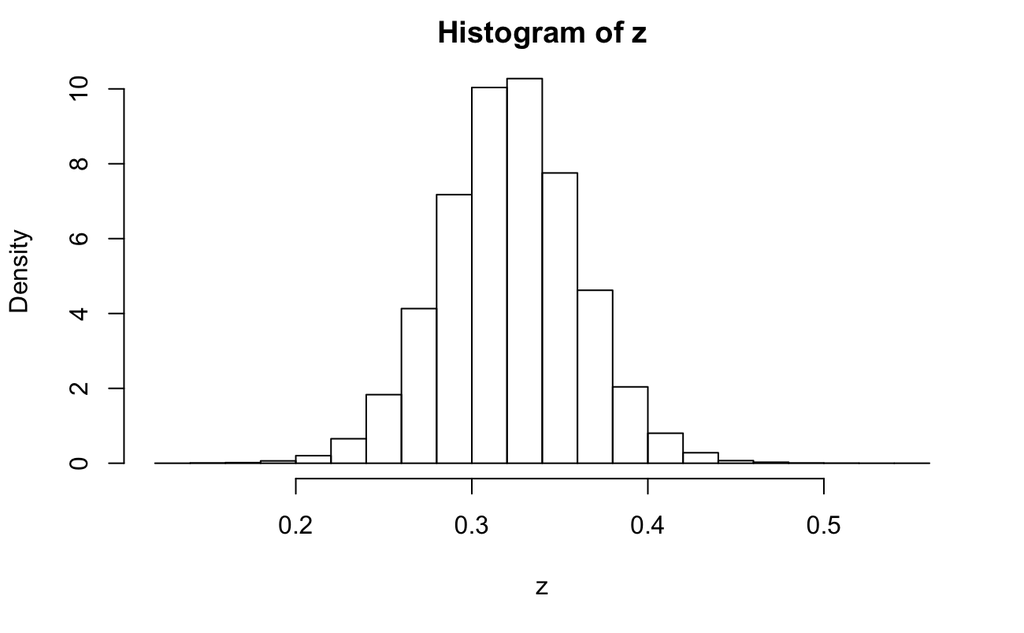

```r
z<-out$beta[,3]
hist(z,freq=FALSE)
abline(v=0,col=2)
```

### La probabilidad final de que Beta3 sea mayor a cero:

```r
1-prob(z)
```

```
[1] 1
```

```r
prob(z)
```

```
[1] 0
```

### Probabilidades - Beta4

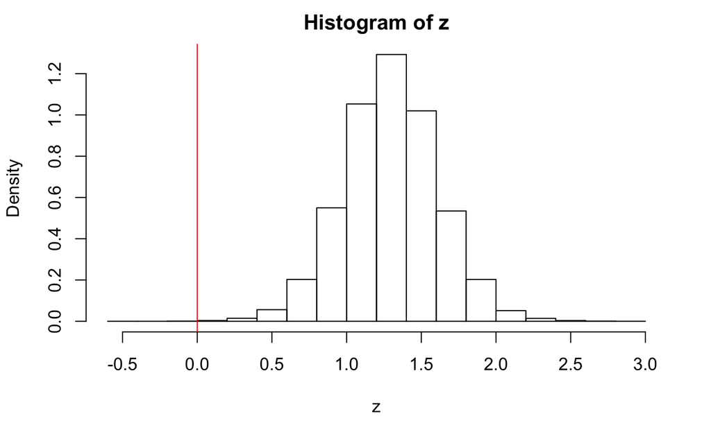

```r
z<-out$beta[,4]
hist(z,freq=FALSE)
abline(v=0,col=2)
```

```r
1-prob(z)
```

```
[1] 0.9998222
```

```r
prob(z)
```

```
[1] 0.0001777778
```

### DIC

```r
out.dic<-ej3.sim$BUGSoutput$DIC
print(out.dic)
```

```
[1] 102.4375
```

### Siempre es importante escalar los datos si están en escalas muy chicas o muy grandes para resolver problemas numéricos.

### Predicciones: el vector out.sum contiene todas las predicciones y quiero filtrar solo las yf para poder graficarlas

```r
out.yf1<-out.sum[grep("yf",rownames(out.sum)),]
or<-order(calif$MO)
ymin<-min(calif$SP,out.yf1[,c(1,3,7)])
ymax<-max(calif$SP,out.yf1[,c(1,3,7)])
par(mfrow=c(1,1))
plot(calif$MO,calif$SP,ylim=c(ymin,ymax))
lines(calif$MO[or],out.yf1[or,1],lwd=2,col=2)
lines(calif$MO[or],out.yf1[or,3],lty=2,col=2)
lines(calif$MO[or],out.yf1[or,7],lty=2,col=2)
lines(calif$MO[or],out.yf2[or,1],lwd=2,col=5)
lines(calif$MO[or],out.yf2[or,3],lty=2,col=5)
lines(calif$MO[or],out.yf2[or,7],lty=2,col=5)
```

[output not shown]